# GDP via API

### Via API Bureau of Economic Analysis

Today we will take a look at the GDP data that is released every month or so by the Bureau of Economic Analysis [BEA](https://www.bea.gov/data/gdp/gross-domestic-product). Before we get started, a big thank you to the BEA who work very hard to gather and clean this data, and then make it publicly available to us dataphiles. We are lucky to live in these data-rich times. I know it’s a government agency and tax-funded, but I’m saying thank you anyway.

Let’s get to the fun stuff. Today, we will first get familiar with the BEA API (see the documentation [here](https://apps.bea.gov/API/bea_web_service_api_user_guide.htm)) and then explore the components of GDP. For a nice read about those components by an excellent writer, check out [this post](https://www.linkedin.com/pulse/four-six-inches-gdp-growth-david-kelly/) by JPMC’s @DavidKelly. For a primer on GDP in general, BEA publishes this [guide](https://www.bea.gov/sites/default/files/methodologies/nipa_primer.pdf).

To access the BEA API, we will need two packages, `httr` and `jsonlite`.

```r
library(httr)
library(jsonlite)
```

```r
"https://apps.bea.gov/api/data/?&UserID=Your-API-Key Here&method=GetData&DataSetName=NIPA&TableName=T10101&Frequency=Q&Year=ALL&ResultFormat=JSON"
```

We supply our API key, and the name of the data set as `NIPA`. We want the table called `T10101`, which holds GDP data, and with a quarterly frequency, so we include `Q`.

We will pass that API string to the `fromJson()` function to access the API, and include `simplifyDataFrame = FALSE` and `simplifyMatrix = FALSE` to turn off some of the builtin data chops.

```r
  bea_gdp_api <-
  fromJSON("https://apps.bea.gov/api/data/?&UserID=084F6B76-36BE-431F-8F2A-54429DF5E04C&method=GetData&DataSetName=NIPA&TableName=T10101&Frequency=Q&Year=ALL&ResultFormat=JSON",
  simplifyDataFrame = FALSE,
  simplifyMatrix = FALSE)

str(bea_gdp_api, max=3)
```

```
List of 1
 $ BEAAPI:List of 2
  ..$ Request:List of 1
  .. ..$ RequestParam:List of 8
  ..$ Results:List of 5
  .. ..$ Statistic        : chr "NIPA Table"
  .. ..$ UTCProductionTime: chr "2018-08-29T16:23:55.823"
  .. ..$ Dimensions       :List of 9
  .. ..$ Data             :List of 7125
  .. ..$ Notes            :List of 1
```

That worked but the returned data is a monster (remove that `max = 3` argument and see what happens)!

Let’s use `pluck()` to extract the data we want by calling `pluck("BEAAPI","Results","Data")`. That command `plucks` the list called `BEAAPI`, then the list called `Results`, then the list called `Data`.

```r
bea_gdp_api <-
  fromJSON("https://apps.bea.gov/api/data/?&UserID=084F6B76-36BE-431F-8F2A-54429DF5E04C&method=GetData&DataSetName=NIPA&TableName=T10101&Frequency=Q&Year=ALL&ResultFormat=JSON",
  simplifyDataFrame = FALSE,
  simplifyMatrix = FALSE) %>%
  pluck("BEAAPI","Results","Data")

str(bea_gdp_api[1])
```

```
List of 1
 $ :List of 9
  ..$ TableName      : chr "T10101"
  ..$ SeriesCode     : chr "A191RL"
  ..$ LineNumber     : chr "1"
  ..$ LineDescription: chr "Gross domestic product"
  ..$ TimePeriod     : chr "1947Q2"
  ..$ METRIC_NAME    : chr "Fisher Quantity Index"
  ..$ CL_UNIT        : chr "Percent change, annual rate"
  ..$ UNIT_MULT      : chr "0"
  ..$ DataValue      : chr "-1.0"
```

Okay, we’re getting somewhere now - a list of 7125 lists of 9 elements. Looking at those 9 elements, we want the `TimePeriod`, the `LineDescription`, the `DataValue` and for reasons we’ll see later, the `SeriesCode`. So, we want 4 items from each of those 7125 lists and ideally we would like to convert them to a tibble.

We can use `map_df()` from `purrr` to apply the `extract()` function from `magrittr` and select just the list elements we want and convert the results to a tibble. By appending `_df` we are telling `map` to return a data frame.

```r
bea_gdp_api <-
  fromJSON("https://apps.bea.gov/api/data/?&UserID=084F6B76-36BE-431F-8F2A-54429DF5E04C&method=GetData&DataSetName=NIPA&TableName=T10101&Frequency=Q&Year=ALL&ResultFormat=JSON",
  simplifyDataFrame = FALSE,
  simplifyMatrix = FALSE) %>%
  pluck("BEAAPI","Results","Data") %>%
  map_df(magrittr::extract, c("LineDescription", "TimePeriod",
                              "SeriesCode", "DataValue"))

str(bea_gdp_api)
```

```
Classes ‘tbl_df’, ‘tbl’ and 'data.frame':   7125 obs. of  4 variables:
 $ LineDescription: chr  "Gross domestic product" "Gross domestic product" "Gross domestic product" "Gross domestic product" ...
 $ TimePeriod     : chr  "1947Q2" "1947Q3" "1947Q4" "1948Q1" ...
 $ SeriesCode     : chr  "A191RL" "A191RL" "A191RL" "A191RL" ...
 $ DataValue      : chr  "-1.0" "-0.8" "6.4" "6.2" ...
```

Much, much better. We now have a tibble, with 4 columns and 7125 rows. Let’s do some cleanup with `rename()` for bettter column names and then make sure that the `percent_change` and `quarter` column are in a good format.

```r
bea_gdp_api <-
  bea_gdp_api %>%
  group_by(LineDescription) %>%
  rename(account = LineDescription, quarter = TimePeriod, percent_change = DataValue) %>%
  mutate(percent_change = as.numeric(percent_change),
         quarter = yq(quarter))
```

```r
bea_gdp_api %>%
  count()
```

| account | n |
| --- | --- |
| Durable goods | 285 |
| Equipment | 285 |
| Exports | 285 |
| Federal | 285 |
| Fixed investment | 285 |
| Goods | 855 |
| Government consumption expenditures and gross investment | 285 |
| Gross domestic product | 285 |
| Gross domestic product, current dollars | 285 |
| Gross private domestic investment | 285 |

[output cut: 11 more lines]

We have 21 accounts or groups. Note there is both `Gross domestic product` and `Gross domestic product, current dollars`, in case that matters to your use case. What are the other 19 groups? They are the sub accounts that comprise GDP. Note that n = 855 for the `Goods` account and the `Services` account, but we have only 285 quarters of data. That’s because there are 3 accounts called `Goods` and `Services` (we’ll look at these three below).

We can look at the `Goods` accounts by `SeriesCode`.

```r
bea_gdp_api %>%
  group_by(SeriesCode) %>%
  slice(1) %>%
  select(account, SeriesCode) %>%
  filter(account == "Goods")
```

| account | SeriesCode |
| --- | --- |
| Goods | A253RL |
| Goods | A255RL |
| Goods | DGDSRL |

This is why we grabbed the series codes, too. We need a way to figure out the true account for these three things labeled as `Goods`.

Some googling reveals that `A253RL` is for Real Exports of Goods (a third level account), `A255RL` is for Real Imports of Goods (a third level account) and `DGDSRL` is a second level account and the `Goods` component of Real Personal Consumption and Expenditure (PCE).

Let’s add better account/group names by with `case_when()`.

```r
bea_gdp_api %>%
  ungroup() %>%
  mutate(account = case_when(SeriesCode == "A253RL" ~ "Export Goods",
                         SeriesCode == "A255RL" ~ "Import Goods",
                         SeriesCode == "DGDSRL" ~ "Goods",
                         TRUE ~ .$account)) %>%
  group_by(account) %>%
  count()
```

| account | n |
| --- | --- |
| Durable goods | 285 |
| Equipment | 285 |
| Export Goods | 285 |
| Exports | 285 |
| Federal | 285 |
| Fixed investment | 285 |
| Goods | 285 |
| Government consumption expenditures and gross investment | 285 |
| Gross domestic product | 285 |
| Gross domestic product, current dollars | 285 |

[output cut: 13 more lines]

We repeat that process for `Services`, which also had 3 accounts smooshed into one label.

```r
bea_gdp_api %>%
  group_by(SeriesCode) %>%
  slice(1) %>%
  select(account, SeriesCode) %>%
  filter(account == "Services")
```

| account | SeriesCode |
| --- | --- |
| Services | A646RL |
| Services | A656RL |
| Services | DSERRL |

Similar to with goods, `DSERRL` is the services component of PCE and is a second level account. `A656RL` is imports of services (a third level account) and `A646RL` is exports of services.

Let’s make our changes to both goods and services in the data. I’m also going to replace a few other accounts with shorter names, e.g. I will use “Govt” for “Government consumption expenditures and gross investment”.

```r
bea_gdp_wrangled <-
  bea_gdp_api %>%
  ungroup() %>%
  mutate(account = case_when(SeriesCode == "A253RL" ~ "Export Goods",
                         SeriesCode == "A255RL" ~ "Import Goods",
                         SeriesCode == "DGDSRL" ~ "Goods",
                         SeriesCode == "DSERRL" ~ "Services",
                         SeriesCode == "A656RL" ~ "Import Services",
                         SeriesCode == "A646RL" ~ "Export Services",
                         SeriesCode == "A822RL" ~ "Govt",
                         SeriesCode == "A006RL" ~ "Investment",
                         SeriesCode == "DPCERL" ~ "PCE",
                         TRUE ~ .$account)) %>%
  group_by(account) %>%
  select(-SeriesCode)

bea_gdp_wrangled %>%
  count()
```

| account | n |
| --- | --- |
| Durable goods | 285 |
| Equipment | 285 |
| Export Goods | 285 |
| Export Services | 285 |
| Exports | 285 |
| Federal | 285 |
| Fixed investment | 285 |
| Goods | 285 |
| Govt | 285 |
| Gross domestic product | 285 |

[output cut: 15 more lines]

We now have 25 accounts, each with 285 observations.

Let’s move to some visualization and check out how GDP has changed on a quarterly basis since 2008

[figure not shown]

```r
bea_gdp_wrangled %>%
filter(quarter > "2008-01-01") %>%
filter(account == "Gross domestic product") %>%
mutate(col_blue =
           if_else(percent_change > 0,
                  percent_change, as.numeric(NA)),
         col_red =
           if_else(percent_change < 0,
                  percent_change, as.numeric(NA))) %>%
  ggplot(aes(x = quarter)) +
  geom_col(aes(y = col_red),
               alpha = .85,
               fill = "pink",
               color = "pink") +
  geom_col(aes(y = col_blue),
               alpha = .85,
               fill = "cornflowerblue",
               color = "cornflowerblue") +
  ylab("Quarterly Change (percent)") +
  scale_x_date(breaks = scales::pretty_breaks(n = 20)) +
  labs(title = "Quarterly GDP Growth",
       subtitle = "since 2000",
       x = "",
       caption = "more here: www.bea.gov/newsreleases/national/gdp/gdpnewsrelease.htm") +
  theme_minimal() +
  theme(axis.text.x = element_text(angle = 90, hjust = 1),
        plot.title = element_text(hjust = 0.5),
        plot.subtitle = element_text(hjust = 0.5),
        plot.caption=element_text(hjust=0))
```

That’s a nice look at GDP quarterly change since 2008, but let’s go a bit deeper and visualize the 4 top level components of GDP, which are personal consumption, net exports (or imports and exports), private investment and government spending. Here is how each changed in Q2 2018.

```r
bea_gdp_wrangled %>%
  filter((
         account == "PCE" |
         account == "Investment" |
         account == "Exports" |
         account == "Imports" |
         account == "Govt") &
        quarter == last(quarter)) %>%
   mutate(col_blue =
           if_else(percent_change > 0,
                  percent_change, as.numeric(NA)),
         col_red =
           if_else(percent_change < 0,
                  percent_change, as.numeric(NA))) %>%
  ggplot(aes(x = reorder(account, percent_change))) +
  geom_col(aes(y = col_red),
               alpha = .85,
               fill = "pink",
               color = "pink",
               width = .5) +
  geom_col(aes(y = col_blue),
               alpha = .85,
               fill = "cornflowerblue",
               color = "cornflowerblue",
               width = .5) +
  labs(title = paste(last(bea_gdp_api$quarter),
                     "GDP Change",
                     sep = " "),
       subtitle = "by account, and total",
       x = "account",
       y = "change last quarter") +
  theme_minimal() +
  theme(axis.text.x = element_text(angle = 90, hjust = 1),
        plot.title = element_text(hjust = 0.5),
        plot.subtitle = element_text(hjust = 0.5)) +
  scale_y_continuous(breaks = scales::pretty_breaks(n = 10))
```

[output not shown]

We can chart how each account has changed over time as well.

[figure not shown]

```r
bea_gdp_wrangled %>%
filter(quarter > "2008-01-01") %>%
filter(
         account == "PCE" |
         account == "Investment" |
         account == "Exports" |
         account == "Imports" |
         account == "Govt") %>%
mutate(col_blue =
           if_else(percent_change > 0,
                  percent_change, as.numeric(NA)),
         col_red =
           if_else(percent_change < 0,
                  percent_change, as.numeric(NA))) %>%
  ggplot(aes(x = quarter)) +
  geom_col(aes(y = col_red),
               alpha = .85,
               fill = "pink",
               color = "pink") +
  geom_col(aes(y = col_blue),
               alpha = .85,
               fill = "cornflowerblue",
               color = "cornflowerblue") +
  ylab("Quarterly Change (percent)") +
  scale_x_date(breaks = scales::pretty_breaks(n = 5)) +
  labs(title = "Quarterly GDP Growth",
       subtitle = "since 2000",
       x = "",
       caption = "more here: www.bea.gov/newsreleases/national/gdp/gdpnewsrelease.htm") +
  theme_minimal() +
  theme(axis.text.x = element_text(angle = 90, hjust = 1),
        plot.title = element_text(hjust = 0.5),
        plot.subtitle = element_text(hjust = 0.5),
        plot.caption=element_text(hjust=0)) +
  facet_wrap(~account)
```

Note that these charts are showing the percent change of each account on an absolute basis, not how each has contributed to GDP change.

Since we might be interested in that sort of thing, let’s use another API call to get a different data set: how each component of GDP has contributed to quarterly change over time. We will use the same flow as above, except specify a different data set with `T10102`.

```r
bea_gdp_contributions <-
  fromJSON("https://apps.bea.gov/api/data/?&UserID=084F6B76-36BE-431F-8F2A-54429DF5E04C&method=GetData&DataSetName=NIPA&TableName=T10102&Frequency=Q&Year=ALL&ResultFormat=JSON",
  simplifyDataFrame = FALSE,
  simplifyMatrix = FALSE) %>%
  pluck("BEAAPI","Results","Data") %>%
  map_df(magrittr::extract, c("LineDescription", "TimePeriod",
                              "SeriesCode", "DataValue")) %>%
  group_by(LineDescription)  %>%
  rename(account = LineDescription, quarter = TimePeriod, percent_change = DataValue) %>%
  mutate(percent_change = as.numeric(percent_change),
         quarter = yq(quarter))
```

Have a quick look at what we just imported.

```r
bea_gdp_contributions %>%
  count()
```

| account | n |
| --- | --- |
| Change in private inventories | 285 |
| Durable goods | 285 |
| Equipment | 285 |
| Exports | 285 |
| Federal | 285 |
| Fixed investment | 285 |
| Goods | 855 |
| Government consumption expenditures and gross investment | 285 |
| Gross domestic product | 285 |
| Gross private domestic investment | 285 |

[output cut: 12 more lines]

```r
NA
NA
```

We have the same naming problem with the `Goods` and `Services` accounts, and note that `Change in private inventories` is included now.

Let’s wrangle as we did before, using the new series codes. We will break up goods and services into three accounts, and do some renaming.

```r
bea_gdp_contributions_wrangled <-
  bea_gdp_contributions %>%
  ungroup() %>%
  mutate(account = case_when(
                         SeriesCode == "A253RY" ~ "Export Goods",
                         SeriesCode == "A191RL" ~ "GDP",
                         SeriesCode == "A255RY" ~ "Import Goods",
                         SeriesCode == "DGDSRY" ~ "Goods",
                         SeriesCode == "DSERRY" ~ "Services",
                         SeriesCode == "A656RY" ~ "Import Services",
                         SeriesCode == "A646RY" ~ "Export Services",
                         SeriesCode == "A019RY" ~ "Net Exports",
                         SeriesCode == "A822RY" ~ "Govt",
                         SeriesCode == "A006RY" ~ "Investment",
                         SeriesCode == "DPCERY" ~ "PCE",
                         SeriesCode == "A014RY" ~ "Inventories",
                         SeriesCode == "Y001RY" ~ "IP",
                         TRUE ~ .$account)) %>%
  group_by(account)
```

Now we are ready to visualize how the various components contributed to the most recent change in GDP.

First, let’s take a look at how the 4 top level components - net exports, consumption, govt spending and investment - contributed to the most recent change in GDP. We start with `ggplot`.

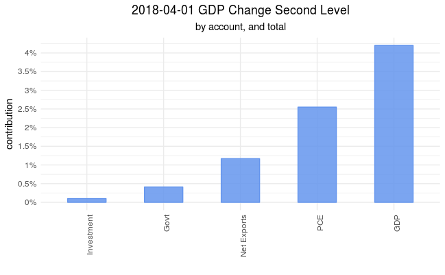

```r
bea_gdp_contributions_wrangled %>%
  filter(
    (account == "GDP" |
    account == "PCE" |
    account == "Investment" |
    account == "Govt" |
    account == "Net Exports") &
    quarter == last(quarter)) %>%
   mutate(col_blue =
           if_else(percent_change > 0,
                  percent_change, as.numeric(NA)),
         col_red =
           if_else(percent_change < 0,
                  percent_change, as.numeric(NA))) %>%
  ggplot(aes(x = reorder(account, percent_change))) +
  geom_col(aes(y = col_red),
               alpha = .85,
               fill = "pink",
               color = "pink",
               width = .5) +
  geom_col(aes(y = col_blue),
               alpha = .85,
               fill = "cornflowerblue",
               color = "cornflowerblue",
               width = .5) +
  labs(title = paste(last(bea_gdp_contributions_wrangled$quarter),
                     "GDP Change Second Level",
                     sep = " "),
       subtitle = "by account, and total",
       x = "",
       y = "contribution") +
  theme_minimal() +
  theme(axis.text.x = element_text(angle = 90, hjust = 1),
        plot.title = element_text(hjust = 0.5),
        plot.subtitle = element_text(hjust = 0.5)) +
  scale_y_continuous(breaks = scales::pretty_breaks(n = 10),
                     labels = function(x) paste0(x, "%"))
```

We see that consumption and next exports led the way in Q2. Let’s delve one level deeper. Consumption is comprised of `Goods` and `Services`, Investment is comprised of `Fixed investment` and `Inventories`, Government is comprised of `Federal` and `State and local`, and Net Exports is comprised of `Exports` and `Imports`. We will filter to include just those second level accounts.

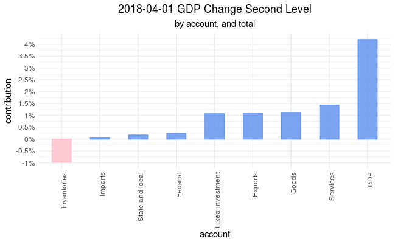

```r
bea_gdp_contributions_wrangled %>%
  filter(
    (account == "GDP" |
       # PCE
       account == "Goods" |
       account == "Services" |
       # Investment
       account == "Fixed investment" |
       account == "Inventories" |
       # Government
       account == "Federal" |
       account == "State and local" |
       # Net Exports
       account == "Exports" |
       account == "Imports") &
      quarter == last(quarter)) %>%
   mutate(col_blue =
           if_else(percent_change > 0,
                  percent_change, as.numeric(NA)),
         col_red =
           if_else(percent_change < 0,
                  percent_change, as.numeric(NA))) %>%
  ggplot(aes(x = reorder(account, percent_change))) +
  geom_col(aes(y = col_red),
               alpha = .85,
               fill = "pink",
               color = "pink",
               width = .5) +
  geom_col(aes(y = col_blue),
               alpha = .85,
               fill = "cornflowerblue",
               color = "cornflowerblue",
               width = .5) +
  labs(title = paste(last(bea_gdp_contributions_wrangled$quarter),
                     "GDP Change Second Level",
                     sep = " "),
       subtitle = "by account, and total",
       x = "account",
       y = "contribution") +
  theme_minimal() +
  theme(axis.text.x = element_text(angle = 90, hjust = 1),
        plot.title = element_text(hjust = 0.5),
        plot.subtitle = element_text(hjust = 0.5)) +
  scale_y_continuous(breaks = scales::pretty_breaks(n = 10),
                     labels = function(x) paste0(x, "%"))
```

A quick glance makes it seem that change in inventories was the only drag on GDP last quarter, while fixed investment, exports, goods and services led the way.

Why stop now - let’s break things down to the next level.

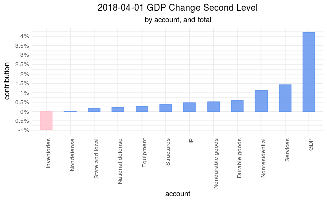

```r
  bea_gdp_contributions_wrangled %>%
  filter(
    (account == "GDP" |
       # PCE goods
       account == "Durable goods" |
       account == "Nondurable goods" |
       account == "Services" |
       # Investment Fixed
       # account == "Residential" |
       account == "Structures" |
       account == "Equipment" |
       account == "IP" |
       account == "Nonresidential" |
       account == "Inventories" |
       # Government Federal
       account == "National defense" |
       account == "Nondefense" |
       account == "State and local" |
       #Exports Imports
       account == "Export goods" |
       account == "Export services" |
       account == "Import goods" |
       account == "Import services") &
      quarter == last(quarter)) %>%
   mutate(col_blue =
           if_else(percent_change > 0,
                  percent_change, as.numeric(NA)),
         col_red =
           if_else(percent_change < 0,
                  percent_change, as.numeric(NA))) %>%
  ggplot(aes(x = reorder(account, percent_change))) +
  geom_col(aes(y = col_red),
               alpha = .85,
               fill = "pink",
               color = "pink",
               width = .5) +
  geom_col(aes(y = col_blue),
               alpha = .85,
               fill = "cornflowerblue",
               color = "cornflowerblue",
               width = .5) +
  labs(title = paste(last(bea_gdp_contributions_wrangled$quarter),
                     "GDP Change Second Level",
                     sep = " "),
       subtitle = "by account, and total",
       x = "account",
       y = "contribution") +
  theme_minimal() +
  theme(axis.text.x = element_text(angle = 90, hjust = 1),
        plot.title = element_text(hjust = 0.5),
        plot.subtitle = element_text(hjust = 0.5)) +
  scale_y_continuous(breaks = scales::pretty_breaks(n = 10),
                     labels = function(x) paste0(x, "%"))
```

```r
NA
```

Next time we will look at GDP change and contributions over time, before porting these visualizations over to `highcharter`. Thanks for reading!